# Exercises Point Patterns

## Exercises Point Patterns

#### From the point pattern of wind turbines shown in section 1.4, download the data as GeoPackage, and read them into R

Download from the “here” link, just above the figure in 1.4; copy the dataset to your working directory, figure out the name (which may vary), then

```r
library(sf)
(w = read_sf("Windkraftanlagen_DE_5521464311407255742.gpkg"))
```

[output not shown]

#### Read the boundary of Germany using …

For this, you may have to install first a high resolution version of the Natural Earth data;

```r
de = rnaturalearth::ne_countries(scale = "large", country = "Germany")
```

#### Create a plot showing both the observation window and the point pattern

Both datasets have a different CRS, so we need to bring them to a common CRS; we take that of the wind turbines, as it is projected (although Pseudo-Mercator is potentially not such a good choice; UTM might be better).

```r
de.pm = st_transform(de, st_crs(w))
```

[output not shown]

```r
plot(st_geometry(de.pm))
```

[output not shown]

```r
plot(w, add = TRUE)
```

[output not shown]

Or using `spatstat`:

```r
library(spatstat)
pp = as.ppp(st_geometry(w), as.owin(de.pm))
```

[output not shown]

```r
plot(pp)
```

[output not shown]

#### Create a ppp object from the points and the window

```r
see above
```

[output not shown]

#### Test whether the point pattern is homogeneous

```r
(pp.test = quadrat.test(pp))
```

[output not shown]

```r
plot(pp.test)
```

[output not shown]

#### Create a plot with the (estimated) density of the wind turbines, with the turbine points added

```r
plot(pp.d <- density(pp))
```

[output not shown]

```r
plot(pp, add = TRUE, col = 'green', cex = .3)
```

[output not shown]

#### Verify that the mean density multiplied by the area of the window approximates the number of turbines

```r
mean(pp.d) * st_area(de.pm) |> units::drop_units()
```

[output not shown]

```r
pp
```

[output not shown]

#### Test for interaction: create diagnostic plots to verify whether the point pattern is clustered, or exhibits repulsion

```r
Lest(pp) |> plot()
```

[output not shown]

```r
Linhom(pp) |> plot()
```

[output not shown]

This however takes a very long time (untried):

```r
envelope(pp, Lest) |> plot()
envelope(ppi, Linhom) |> plot()
```

## Exercises Geostatistics.

#### Compute the variogram cloud of NO2 using `variogram()` and argument `cloud = TRUE`. (a) How does the resulting object differ from the “regular” variogram (use the `head` command on both objects); (b) what do the “left” and “right” fields refer to? © when we plot the resulting variogram cloud object, does it still indicate spatial correlation?

```r
library(sf)
no2 <- read.csv(system.file("external/no2.csv",
    package = "gstat"))
crs <- st_crs("EPSG:32632") # a csv doesn't carry a CRS!
st_as_sf(no2, crs = "OGC:CRS84", coords =
    c("station_longitude_deg", "station_latitude_deg")) |>
    st_transform(crs) -> no2.sf
library(gstat)
```

```r
vc = variogram(NO2~1, no2.sf, cloud = TRUE)
head(vc)
```

```
##        dist      gamma dir.hor dir.ver   id left right
## 1 291778.27 0.04614575       0       0 var1    3     1
## 2 260594.88 0.80888009       0       0 var1    4     1
## 3  33040.20 0.46862512       0       0 var1    4     3
## 4 264858.84 0.63022274       0       0 var1    5     1
## 5  28838.01 0.33529899       0       0 var1    5     3
## 6  20620.76 0.01113277       0       0 var1    5     4
```

“left” and “right” point to the row numbers of the original data points contriting to the gamma value

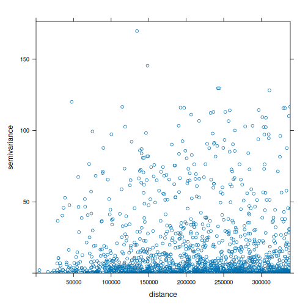

```r
plot(vc)
```

It’s hard to see; individual points are `\chi(1)` distributed, so very skew; with some efforts one can see that mean values for lower lag values are smaller than those for larger lags.

#### Compute the variogram of NO2 as above, and change the arguments `cutoff` and `width` into very large or small values. What do they do?

```r
(vc = variogram(NO2~1, no2.sf, cutoff = 40000, width = 1000))
```

```
##    np      dist       gamma dir.hor dir.ver   id
## 1   2  4296.912  1.06394556       0       0 var1
## 2   1 15723.581  0.93800438       0       0 var1
## 3   1 20620.764  0.01113277       0       0 var1
## 4   1 21796.700  0.46602161       0       0 var1
## 5   1 23820.047  1.95623826       0       0 var1
## 6   1 25109.710  0.07459796       0       0 var1
## 7   1 27960.968  0.56775963       0       0 var1
## 8   4 28554.857 11.46829978       0       0 var1
## 9   2 29788.392 10.60204268       0       0 var1
## 10  4 31533.716  2.84874564       0       0 var1
## 11  1 32635.070  5.27022981       0       0 var1
## 12  2 33040.807  0.36960625       0       0 var1
## 13  2 35469.344 21.40477439       0       0 var1
## 14  3 36363.856 15.95415600       0       0 var1
## 15  2 38569.572 26.91513472       0       0 var1
```

`cutoff` is the maximum distance, `width` the interval width (lag size).

#### Fit a spherical model to the sample variogram of NO2, using `fit.variogram()` (follow the example below, replace “Exp” with “Sph”)

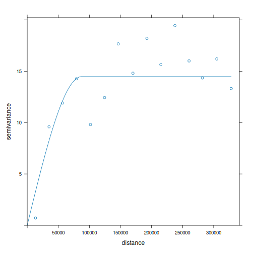

```r
v = variogram(NO2~1, no2.sf)
v.fit.e = fit.variogram(v, vgm(1, "Exp", 50000))
v.fit.s = fit.variogram(v, vgm(1, "Sph", 50000))
plot(v, v.fit.s)
```

```r
v.fit.e
```

```
##   model    psill    range
## 1   Exp 16.25404 52356.94
```

```r
v.fit.s
```

```
##   model    psill    range
## 1   Sph 14.48484 87594.92
```

As you can see, the spherical model levels at the range value, it doesn’t reach a plateau asymptotically as exponential does.

#### Fit a Matern model (“Mat”) to the sample variogram using different values for kappa (e.g., 0.3 and 4), and plot the resulting models with the sample variogram.

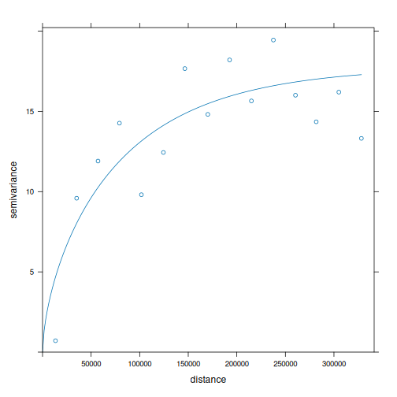

```r
v.fit.m1 = fit.variogram(v, vgm(1, "Mat", 50000, kappa = .3))
plot(v, v.fit.m1)
```

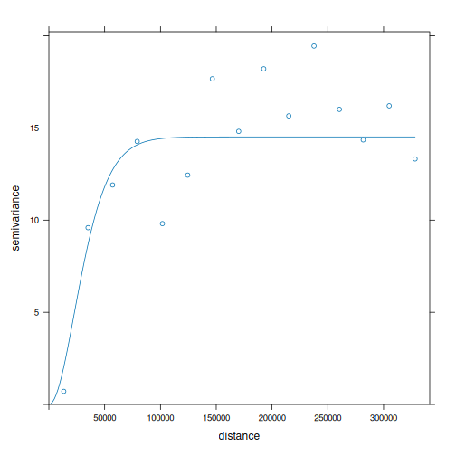

```r
v.fit.m2 = fit.variogram(v, vgm(1, "Mat", 50000, kappa = 4))
plot(v, v.fit.m2)
```

```r
v.fit.m1
```

```
##   model    psill    range kappa
## 1   Mat 17.78662 111045.6   0.3
```

```r
v.fit.m2
```

```
##   model   psill    range kappa
## 1   Mat 14.5161 9773.191     4
```

#### Which model do you like the best? Can the SSErr attribute of the fitted model be used to compare the models? How else can variogram model fits be compared?

We can plot all models in a single plot, e.g. by

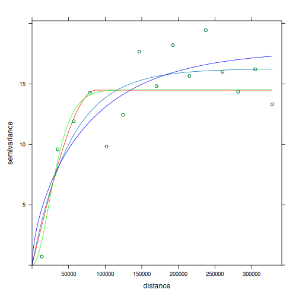

```r
p.exp <- plot(v, v.fit.e)
p.sph <- plot(v, v.fit.s, col="red")
p.mat1 <- plot(v, v.fit.m1, col="blue")
p.mat2 <- plot(v, v.fit.m2, col="green")
p.exp +
  latticeExtra::as.layer(p.sph) +
  latticeExtra::as.layer(p.mat1) +
  latticeExtra::as.layer(p.mat2)
```

Comparing SSErr:

```r
attr(v.fit.e, "SSErr")
```

```
## [1] 6.427299e-07
```

```r
attr(v.fit.s, "SSErr")
```

```
## [1] 6.301292e-07
```

```r
attr(v.fit.m1, "SSErr")
```

```
## [1] 8.464766e-07
```

```r
attr(v.fit.m2, "SSErr")
```

```
## [1] 4.674051e-07
```

indicating that from these four, m2 is “best”

`SSErr` is a *weighted* sum of squares; as long as the weights are not derived from the fitted model, then they can be compared. By default (`fit.method=7`) this is the not the case, so they can be compared.

Another way of comparing the “goodness” of variogram models is to use them in a cross validation setting: then they are compared for their purpose, which is spatial prediction.

```r
cv.e = krige.cv(NO2~1, no2.sf, v.fit.e)
cv.s = krige.cv(NO2~1, no2.sf, v.fit.s)
cv.m1 = krige.cv(NO2~1, no2.sf, v.fit.m1)
cv.m2 = krige.cv(NO2~1, no2.sf, v.fit.m2)
mean(cv.e$zscore^2) |> sqrt() # RMSPE of cv
```

```
## [1] 1.158028
```

```r
mean(cv.s$zscore^2) |> sqrt() # RMSPE of cv
```

```
## [1] 1.250356
```

```r
mean(cv.m1$zscore^2) |> sqrt() # RMSPE of cv
```

```
## [1] 1.117519
```

```r
mean(cv.m2$zscore^2) |> sqrt() # RMSPE of cv
```

```
## [1] 1.274814
```

indicating that from these four, m1 is “best”

## Exercises Lattice data

#### Compare the results of the simple linear regression with the spatial error model

```r
library(sf)
data(pol_pres15, package = "spDataLarge")
pol_pres15 <- st_make_valid(pol_pres15)
library(spdep)
pol_pres15 |> poly2nb(queen = TRUE) -> nb_q
(nb_q |> nb2listw(style = "B") -> lw_q_B)
```

```
## Characteristics of weights list object:
## Neighbour list object:
## Number of regions: 2495
## Number of nonzero links: 14242
## Percentage nonzero weights: 0.2287862
## Average number of links: 5.708216
##
## Weights style: B
## Weights constants summary:
##      n      nn    S0    S1     S2
## B 2495 6225025 14242 28484 357280
```

```r
form = I_turnout ~ I_entitled_to_vote
(lm0 <- lm(form, pol_pres15)) |> summary()
```

```
##
## Call:
## lm(formula = form, data = pol_pres15)
##
## Residuals:
##      Min       1Q   Median       3Q      Max
## -0.21352 -0.04387 -0.00092  0.04150  0.23611
##
## Coefficients:
##                     Estimate Std. Error t value Pr(>|t|)
## (Intercept)        4.390e-01  1.338e-03   328.2   <2e-16 ***
## I_entitled_to_vote 5.260e-07  4.176e-08    12.6   <2e-16 ***
## ---
## Signif. codes:  0 '***' 0.001 '**' 0.01 '*' 0.05 '.' 0.1 ' ' 1
##
## Residual standard error: 0.06178 on 2493 degrees of freedom
## Multiple R-squared:  0.05983,	Adjusted R-squared:  0.05945
## F-statistic: 158.6 on 1 and 2493 DF,  p-value: < 2.2e-16
```

```r
library(spatialreg)
SEM_pres <- errorsarlm(form, data = pol_pres15, Durbin = FALSE,
      listw = lw_q_B, zero.policy = TRUE)
SEM_pres |> summary()
```

```
##
## Call:errorsarlm(formula = form, data = pol_pres15, listw = lw_q_B,
##     Durbin = FALSE, zero.policy = TRUE)
##
## Residuals:
##        Min         1Q     Median         3Q        Max
## -0.1483326 -0.0266702 -0.0025573  0.0217927  0.1659212
##
## Type: error
## Coefficients: (asymptotic standard errors)
##                      Estimate Std. Error  z value  Pr(>|z|)
## (Intercept)        4.5887e-01 2.3544e-03 194.8968 < 2.2e-16
## I_entitled_to_vote 6.8492e-08 2.5677e-08   2.6675  0.007642
##
## Lambda: 0.13816, LR test value: 1964.5, p-value: < 2.22e-16
## Asymptotic standard error: 0.0020534
##     z-value: 67.286, p-value: < 2.22e-16
## Wald statistic: 4527.4, p-value: < 2.22e-16
##
## Log likelihood: 4389.657 for error model
## ML residual variance (sigma squared): 0.0014662, (sigma: 0.038291)
## Number of observations: 2495
## Number of parameters estimated: 4
## AIC: -8771.3, (AIC for lm: -6808.8)
```

The effect of `I_entitled_to_vote` is smaller and less significant in the spatial error model, the sign is identical. The spatial effect has “consumed” some of the variability in the data.

#### Compare the maps of residuals of both models

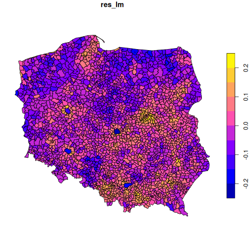

```r
pol_pres15$res_lm = residuals(lm0)
plot(pol_pres15["res_lm"])
```

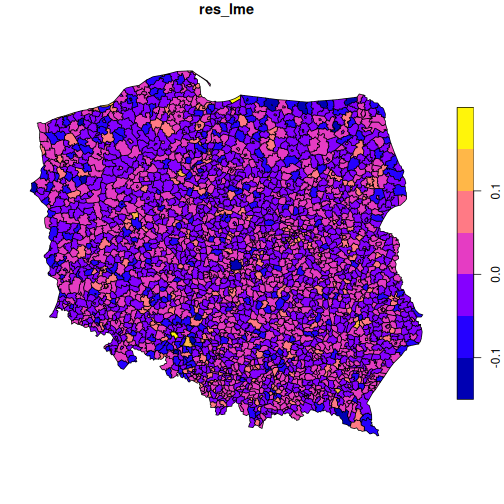

```r
pol_pres15$res_lme = residuals(SEM_pres)
plot(pol_pres15["res_lme"])
```

#### Fit a spatial Durbin error model (SDEM), using `Durbin = TRUE` in the same call to `errorsarlm`; compare the output of the Spatial Durbin model with that of the error model.

```r
SEM_pres_d <- errorsarlm(form, data = pol_pres15, Durbin = TRUE,
      listw = lw_q_B, zero.policy = TRUE)
SEM_pres_d |> summary()
```

```
##
## Call:errorsarlm(formula = form, data = pol_pres15, listw = lw_q_B,
##     Durbin = TRUE, zero.policy = TRUE)
##
## Residuals:
##         Min          1Q      Median          3Q         Max
## -0.15411751 -0.02411994 -0.00020957  0.02339365  0.17254487
##
## Type: error
## Coefficients: (asymptotic standard errors)
##                           Estimate  Std. Error  z value  Pr(>|z|)
## (Intercept)             4.5606e-01  2.3612e-03 193.1470 < 2.2e-16
## I_entitled_to_vote      3.2466e-07  3.3842e-08   9.5933 < 2.2e-16
## lag.(Intercept)        -4.3777e-03  6.9692e-04  -6.2815 3.352e-10
## lag.I_entitled_to_vote  1.4335e-07  1.3485e-08  10.6304 < 2.2e-16
##
## Lambda: 0.13271, LR test value: 1778.6, p-value: < 2.22e-16
## Asymptotic standard error: 0.0023538
##     z-value: 56.38, p-value: < 2.22e-16
## Wald statistic: 3178.7, p-value: < 2.22e-16
##
## Log likelihood: 4451.348 for error model
## ML residual variance (sigma squared): 0.0014223, (sigma: 0.037713)
## Number of observations: 2495
## Number of parameters estimated: 6
## AIC: -8890.7, (AIC for lm: -7114.1)
```

We see a larger and more significant effect of `I_entitled_to_vote`, and also significant effects of lagged intercept and lagged predictor.

#### carry out a likelyhood ratio test to compare the SEM and SDEM models (`lmtest::lrtest()`, see the SDS book Ch 17)

```r
lmtest::lrtest(SEM_pres, SEM_pres_d)
```

```
## Likelihood ratio test
##
## Model 1: I_turnout ~ I_entitled_to_vote
## Model 2: I_turnout ~ I_entitled_to_vote
##   #Df LogLik Df  Chisq Pr(>Chisq)
## 1   4 4389.7
## 2   6 4451.3  2 123.38  < 2.2e-16 ***
## ---
## Signif. codes:  0 '***' 0.001 '**' 0.01 '*' 0.05 '.' 0.1 ' ' 1
```

The LR test suggest there is a significant improvement.